# AutomateVersionTranslation

Transition from E+ 22.2.0 to E+ 23.1.0

Foreword

**This notebook has two big parts:**

- **Part 1:** aims to transition all regression tests from one E+ version to the next, and allows you to run each test in both the old and the new version
  - These will take quite some time to run (about 1hr to run the tests in the OLD OpenStudio version, transition the IDFs to the new E+ version and run them, and run the tests in the NEW OpenStudio Version, based on almost 200 files currently)
  - By default it will just copy over the SQL from the regression test to place in OLD_DIR, but if you want to force rerun the IDF in the old E+ version you can.
  - At the end of Part 1, you will have three CSV files, one per version, with the site KBTUs for each test. And you also have an organized tree of VERSION/TEST_NAME/ output directories that have the SQL files we will use for sections 6+.
- **Part 2:** aims to analyze the differences between versions
  - Section 3.1 just re-queries all SQL file (or you can reload the three CSV files) to highlight the tests with the biggest site KBTU differences
  - Section 3.2 provides a high-level interface that only requires to pass a test name and it will query the relevant SQL files and produce visualization (tables, grouped bar charts, and heatmaps) to analyze where differences may be coming from

  If you have already run Part 1 successfully once, you only need to run Section 1. and you can jump to Part 2 directly.

# PART 1: Transition all regression tests and run them in both E+ versions

**Part 1 is ommited in the HTML because the interesting part is the output and analysis at the end**

# PART 2: Analyzing differences

## Analyzing E+ runtime

**THIS NO LONGER WORKS, last version where it worked was 9.2.0... I don't know where the runtime went in the SQLFile**

## Concat frames and look at files that failed to run

| E+ OS | 22.2.0-aa78da9668 3.5.1 | 23.1.0-ff86a13c18 Transition | 23.1.0-87ed9199d4 3.6.0 |
| --- | --- | --- | --- |
| ems_scott.osm | 29097.985594 | 29097.985594 | None |
| heatrecovery_chiller.osm | 5231467.117398 | nan | 5231467.117398 |
| heatrecovery_chiller.rb | 5231467.117398 | nan | 5231467.117398 |
| storage_liion_battery.osm | 2089235.365622 | None | 2089235.365622 |
| storage_liion_battery.rb | 2089235.365622 | None | 2089235.365622 |

## First look at where we have deviations

```
Setting % diff threshold to 0.010%
```

### Deviations in Transition and/or new OpenStudio

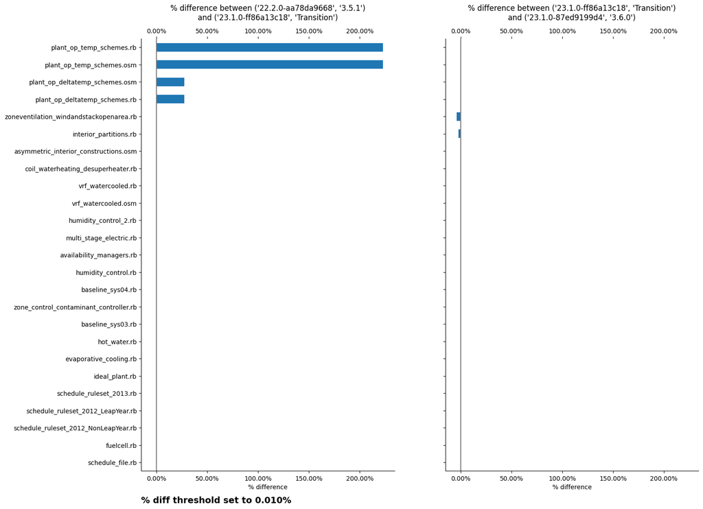

### Deviations from Transition to new OS only

```
Deviations from Transition to new OS only: Differences above 0.010%
```

| E+ OS | 23.1.0-ff86a13c18 Transition | 23.1.0-87ed9199d4 3.6.0 |
| --- | --- | --- |
| schedule_file.rb | 0.000% | -0.020% |
| fuelcell.rb | 0.000% | -0.021% |
| schedule_ruleset_2012_NonLeapYear.rb | 0.000% | -0.022% |
| schedule_ruleset_2012_LeapYear.rb | 0.000% | -0.022% |
| schedule_ruleset_2013.rb | 0.000% | -0.022% |
| ideal_plant.rb | 0.000% | -0.022% |
| evaporative_cooling.rb | 0.000% | -0.022% |
| hot_water.rb | 0.000% | -0.022% |
| baseline_sys03.rb | 0.000% | -0.022% |
| zone_control_contaminant_controller.rb | 0.000% | -0.023% |
| baseline_sys04.rb | 0.000% | -0.025% |
| humidity_control.rb | 0.000% | -0.035% |
| availability_managers.rb | 0.000% | -0.068% |
| multi_stage_electric.rb | 0.000% | -0.091% |
| humidity_control_2.rb | 0.000% | -0.136% |
| coil_waterheating_desuperheater.rb | 0.000% | -0.207% |
| asymmetric_interior_constructions.osm | 0.000% | 0.679% |
| interior_partitions.rb | 0.000% | -2.257% |
| zoneventilation_windandstackopenarea.rb | 0.000% | -3.769% |

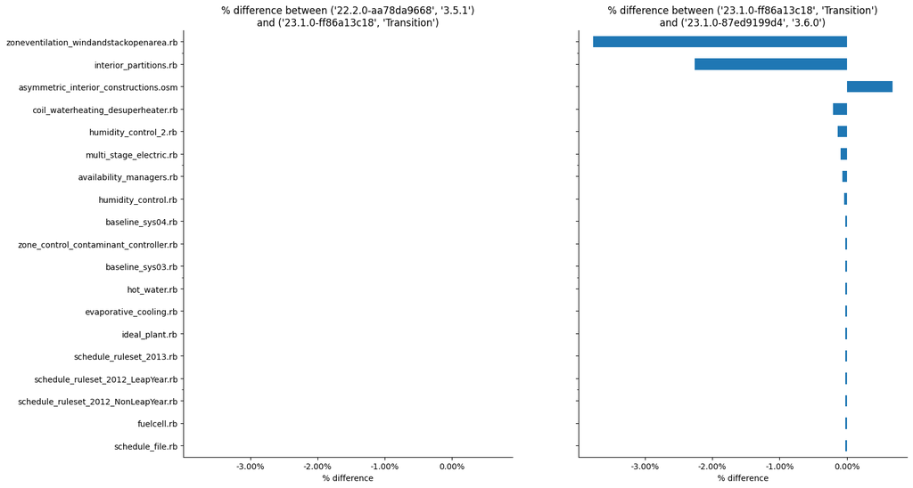

| E+ OS | 22.2.0-aa78da9668 3.5.1 | 23.1.0-ff86a13c18 Transition | 23.1.0-87ed9199d4 3.6.0 |
| --- | --- | --- | --- |
| surface_properties_lwr.rb | 1950437.026523 | 1950437.026523 | 1950437.026523 |
| surface_properties_lwr.osm | 1950437.026523 | 1950437.026523 | 1950437.026523 |

## Grouped bar chart of differences compared to the old OpenStudio

**How to read this chart** :

The percentage differences are calculated compared to the Old OpenStudio results for both the transitioned results and the new OpenStudio results.

**What you need to pay special attention to is when you don't have the same difference between the Transition to Old OS and the New OS to old OS** (meaning the difference is not E+'s fault, but OpenStudio's).

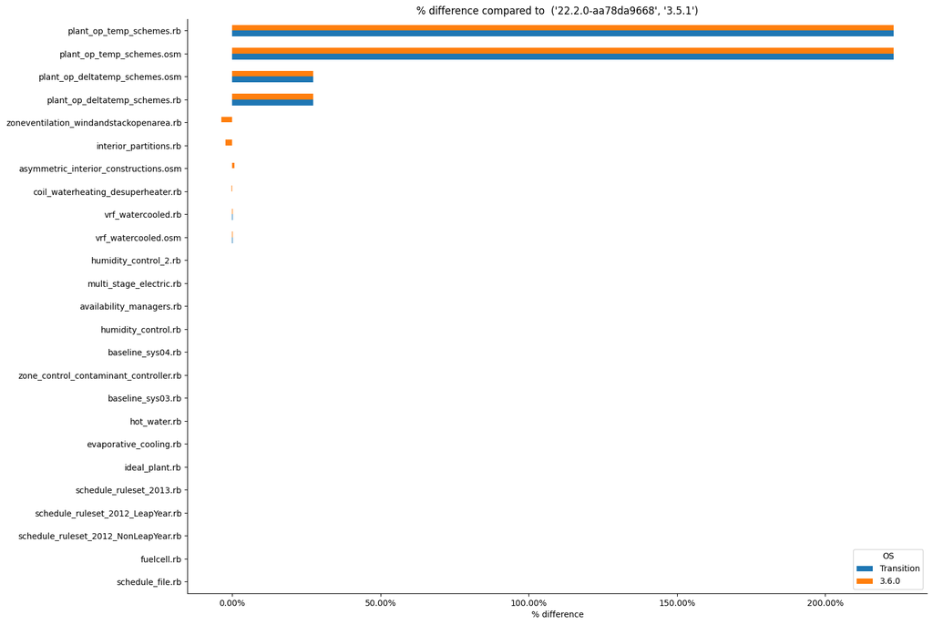

| OS | Transition | 3.6.0 |
| --- | --- | --- |
| plant_op_temp_schemes.rb | 223.07% | 223.07% |
| plant_op_temp_schemes.osm | 223.07% | 223.07% |
| plant_op_deltatemp_schemes.osm | 27.24% | 27.24% |
| plant_op_deltatemp_schemes.rb | 27.24% | 27.24% |
| zoneventilation_windandstackopenarea.rb | 0.00% | -3.77% |
| interior_partitions.rb | 0.00% | -2.26% |
| asymmetric_interior_constructions.osm | 0.00% | 0.68% |
| coil_waterheating_desuperheater.rb | 0.00% | -0.21% |
| vrf_watercooled.rb | 0.17% | 0.17% |
| vrf_watercooled.osm | 0.16% | 0.16% |
| humidity_control_2.rb | 0.00% | -0.14% |
| multi_stage_electric.rb | 0.00% | -0.09% |
| availability_managers.rb | 0.00% | -0.07% |
| humidity_control.rb | 0.00% | -0.04% |
| baseline_sys04.rb | 0.00% | -0.03% |
| zone_control_contaminant_controller.rb | 0.00% | -0.02% |
| baseline_sys03.rb | 0.00% | -0.02% |
| hot_water.rb | 0.00% | -0.02% |
| evaporative_cooling.rb | 0.00% | -0.02% |
| ideal_plant.rb | 0.00% | -0.02% |
| schedule_ruleset_2013.rb | 0.00% | -0.02% |
| schedule_ruleset_2012_LeapYear.rb | 0.00% | -0.02% |
| schedule_ruleset_2012_NonLeapYear.rb | 0.00% | -0.02% |
| fuelcell.rb | 0.00% | -0.02% |
| schedule_file.rb | 0.00% | -0.02% |

## Stacked bar chart of differences

**How to read this chart** :

The percentage differences are calculated compared to the Old OpenStudio results for both the transitioned results and the new OpenStudio results. Then I do

```
% diff New version = % diff New version - % diff Transition
```

and plot that as a stacked bar chart. The goal is to more clearly see the differences that are due to OpenStudio by removing the differences due to the new E+.

**What you need to pay special attention to is when you see % differences for the new OS.**

**A cursor along with the total % difference between Old OS and New OS is also plotted** . Please see the below example to get a better sense of how the graph is constructed

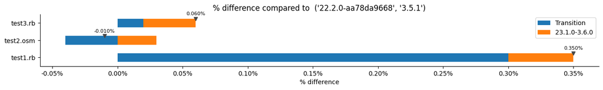

**Let's do the actual plotting now:**

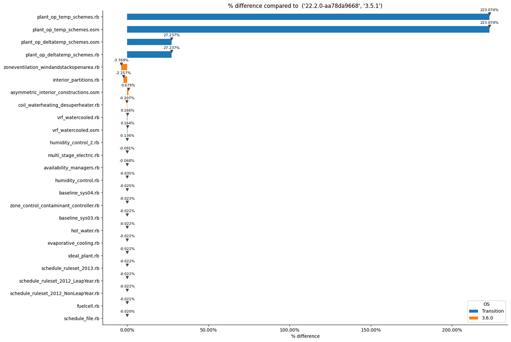

## Inspect biggest differences

### Single test

Absolute diff for plant_op_temp_schemes.rb **Comparing each version to 22.2.0-3.5.1**

| Version FuelType Units EndUse | 23.1.0-Transition Electricity GJ | 23.1.0-Transition Natural Gas GJ | 23.1.0-Transition Water m3 | 23.1.0-3.6.0 Electricity GJ | 23.1.0-3.6.0 Natural Gas GJ | 23.1.0-3.6.0 Water m3 |
| --- | --- | --- | --- | --- | --- | --- |
| Heating | - | 4844 | - | - | 4844 | - |
| Cooling | 592 | - | - | 592 | - | - |
| Fans | -54 | - | - | -54 | - | - |
| Pumps | 142 | - | - | 142 | - | - |
| Heat Rejection | 173 | - | 258137 | 173 | - | 258137 |

Relative individual % diff for each end use and fuel for 'plant_op_temp_schemes.rb' **Comparing each version to 22.2.0-3.5.1**

| Version FuelType Units EndUse | 23.1.0-Transition Electricity GJ | 23.1.0-Transition Natural Gas GJ | 23.1.0-Transition Water m3 | 23.1.0-3.6.0 Electricity GJ | 23.1.0-3.6.0 Natural Gas GJ | 23.1.0-3.6.0 Water m3 |
| --- | --- | --- | --- | --- | --- | --- |
| Heating | - | inf% | - | - | inf% | - |
| Cooling | inf% | - | - | inf% | - | - |
| Fans | -50.86% | - | - | -50.86% | - | - |
| Pumps | 58.32% | - | - | 58.32% | - | - |
| Heat Rejection | inf% | - | inf% | inf% | - | inf% |

% diff of total GJ/m3 plant_op_temp_schemes.rb **Comparing each version to 22.2.0-3.5.1**

| Type Units EndUse | 23.1.0-Transition Energy GJ | 23.1.0-Transition Water m3 | 23.1.0-3.6.0 Energy GJ | 23.1.0-3.6.0 Water m3 |
| --- | --- | --- | --- | --- |
| Heating | 189.68% | - | 189.68% | - |
| Cooling | 23.17% | - | 23.17% | - |
| Fans | -2.11% | - | -2.11% | - |
| Pumps | 5.56% | - | 5.56% | - |
| Heat Rejection | 6.77% | inf% | 6.77% | inf% |

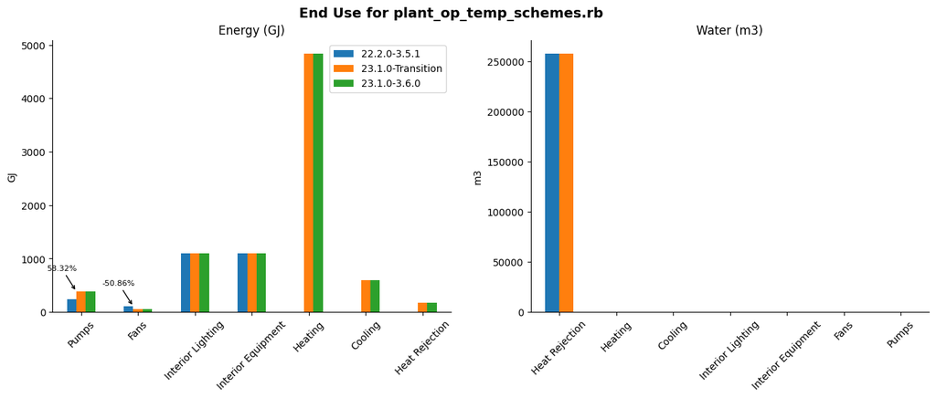

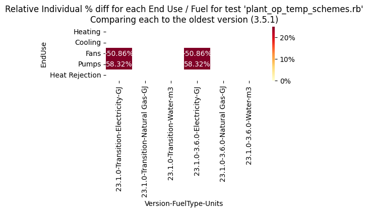

#### Inspect in more detail

```
Investigating the test='plant_op_temp_schemes.rb'
```

```
Deviations in end uses for test='plant_op_temp_schemes.rb'
```

| Version FuelType Units EndUse | 22.2.0-3.5.1 Electricity GJ | 23.1.0-Transition Electricity GJ | 23.1.0-Transition Natural Gas GJ | 23.1.0-Transition Water m3 | 23.1.0-3.6.0 Electricity GJ | 23.1.0-3.6.0 Natural Gas GJ | 23.1.0-3.6.0 Water m3 |
| --- | --- | --- | --- | --- | --- | --- | --- |
| Heating | NaN | NaN | 4843.94 | NaN | NaN | 4843.94 | NaN |
| Cooling | NaN | 591.74 | NaN | NaN | 591.74 | NaN | NaN |
| Interior Lighting | 1102.13 | 1102.13 | NaN | NaN | 1102.13 | NaN | NaN |
| Interior Equipment | 1102.13 | 1102.13 | NaN | NaN | 1102.13 | NaN | NaN |
| Fans | 105.81 | 51.99 | NaN | NaN | 51.99 | NaN | NaN |
| Pumps | 243.68 | 385.79 | NaN | NaN | 385.79 | NaN | NaN |
| Heat Rejection | NaN | 172.79 | NaN | 258137.22 | 172.79 | NaN | 258137.22 |

Relative individual % diff for each end use and fuel for 'plant_op_temp_schemes.rb' **Comparing from one version to the next**

| Version FuelType Units EndUse | 23.1.0-Transition Electricity GJ | 23.1.0-Transition Natural Gas GJ | 23.1.0-Transition Water m3 |
| --- | --- | --- | --- |
| Heating | - | inf% | - |
| Cooling | inf% | - | - |
| Fans | -50.86% | - | - |
| Pumps | 58.32% | - | - |
| Heat Rejection | inf% | - | inf% |

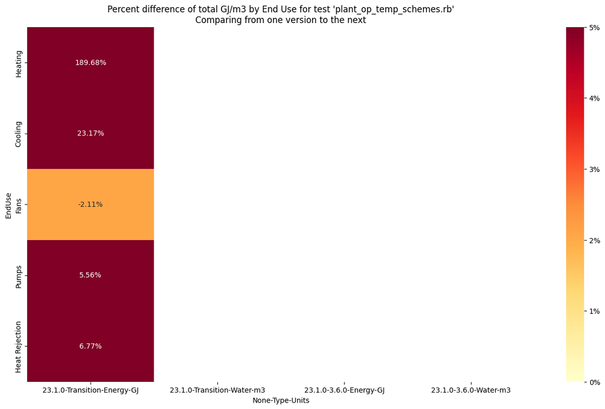

### Multiple Tests - one per row

```
Reporting for 6 largest differences in Transition to New OS
```

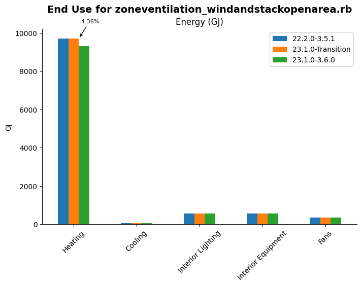

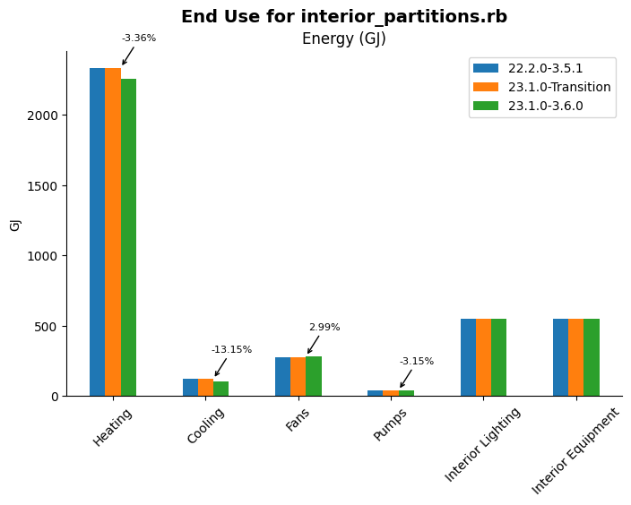

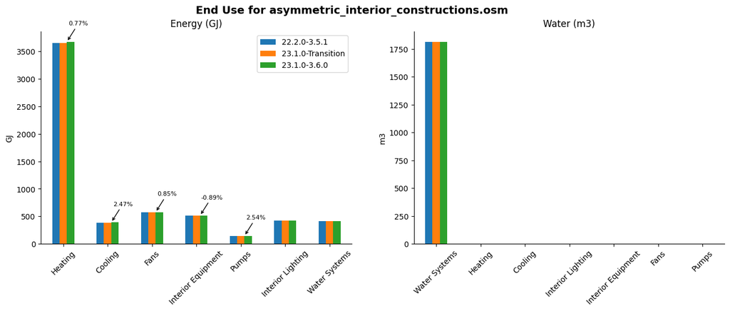

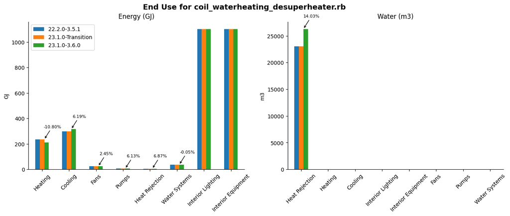

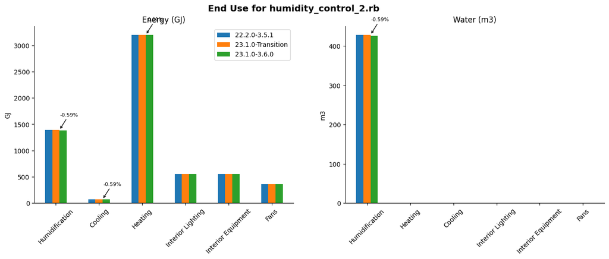

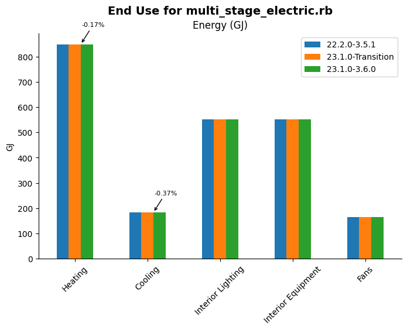

### Multiple Tests - in a grid

```
Reporting for 6 largest differences in Transition to New OS
```

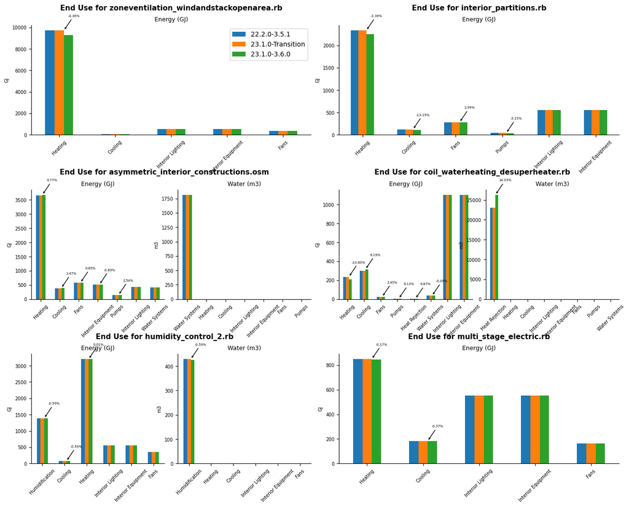

### Multiple Tests - heatmaps

```
Reporting for 10 largest differences in Transition to New OS
```

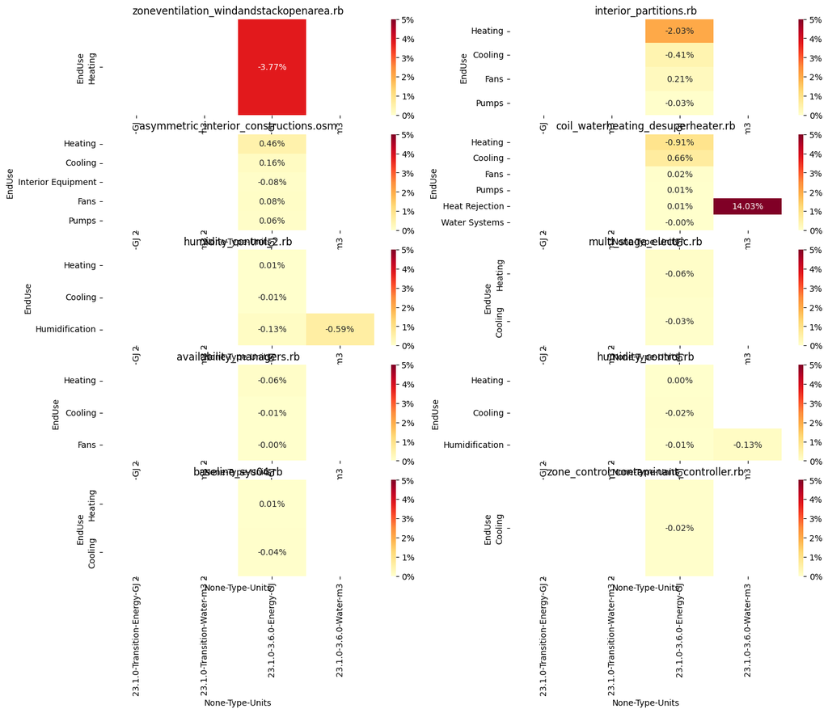